# Monday, October 5th, 2026

Last week, we continued discussing using `matplotlib.pyplot` to visualize Python data, and began working `numpy` arrays. We also spent time working on our second project, which deals with Pythagorean triples.

## Primitive Pythagorean triples

It will be useful for the project to consider what are called, "primitive Pythagorean triples". We say that a Pythagorean triple $(a,b,c)$ is *primitive* if the greatest common divisor of $a$, $b$, and $c$ is $1$.

**Math exercise:** A Pythagorean triple $(a,b,c)$ is primitive if and only if the greatest common divisor of $a$ and $b$ is $1$.

Recall from the project page that a pair of integers $(a,b)$ is a *Pythagorean double* if there as integer $c$ such that $(a,b,c)$ is a Pythagorean triple. In light of the math exercise above, we will call a Pythagorean double $(a,b)$ *primitive* if $a$ and $b$ have greatest common divisor $1$.

In addition to plotting all Pythagorean doubles in a given range, it will be useful to also plot only the primitive Pythagorean doubles. To that end, can we calculated greatest common divisors? Let's write our own `greatest_common_divisor` function.

```python
def greatest_common_divisor(a,b):
    gcd = 1
    for d in range(1,min(a,b)):
        if (a % d == 0) and (b % d == 0): # If d divides both a and b
            gcd = d
    return gcd
```

```python
greatest_common_divisor(100,102)
```

```
2
```

```python
greatest_common_divisor(100,150)
```

```
50
```

Another method of calculating greatest common divisors is known as *the Euclidean algorithm*. The algorithm is based on the following facts.

- If $d$ divides both $a$ and $b$, then $d$ must also divide $b - a$.
- If $d$ divides both $a$ and $b-a$, then $d$ must also divide $b$.

Putting these together, we see that the greatest common divisor of $a$ and $b$ is exactly the same as the greatest common divisor of $a$ and $b-a$. The algorithm then proceeds as follows.

1. Start with integers $a$ and $b$, and assume that $a \leq b$.
2. Subtract the smaller $a$ from the larger $b$, and replace the larger $b$ with the difference $b - a$.
3. Repeat step 2 until one of the numbers is $0$. The other will be the greatest common divisor.

**Exercise:** Write a function to implement the Euclidean algorithm

```python
def Euclidean_algorithm(a,b):
    while (a != 0) and (b != 0):
        if b < a:          # If b is the smaller value
            a, b = b, a    # swap a and b
        b = b - a          # Subtract smaller from larger
    return max(a,b)        # GCD is the non-zero value
```

```python
def Euclidean_algorithm(a,b):
    while (a != 0) and (b != 0):
        if b < a:          # If b is the smaller value
            a, b = b, a    # swap a and b
        b = b % a          # Subtract smaller from larger
    return max(a,b)        # GCD is the non-zero value
```

```python
Euclidean_algorithm(100,150)
```

```
50
```

```python
Euclidean_algorithm(100,102)
```

```
2
```

**Exercise:** Time the two approaches above for finding the greatest common divisor of $a=455\cdot 10^6$ and $b=455\cdot 10^6 + 1$.

```python
a = 455*10**6
b = a + 1

import time
```

```python
t0 = time.time()
print('GCD:', greatest_common_divisor(a,b))
t1 = time.time()
print('Elapsed time:', t1-t0)
```

```
GCD: 1
Elapsed time: 34.64339900016785
```

```python
t0 = time.time()
print('GCD:', Euclidean_algorithm(a,b))
t1 = time.time()
print('Elapsed time:', t1-t0)
```

```
GCD: 1
Elapsed time: 0.00018739700317382812
```

**Exercise:** Write a function `is_prim_ptriple` that takes in a Pythagorean triple and returns `True` if that triple is primitive and `False` otherwise.

```python
def is_prim_ptriple(ptriple):
    a = ptriple[0]
    b = ptriple[1]
    c = ptriple[2]
    gcd_ab = Euclidean_algorithm(a,b)
    gcd_abc = Euclidean_algorithm(gcd_ab, c)

    if gcd_abc == 1:
        return True
    else:
        return False
```

```python
is_prim_ptriple([3,4,5])
```

```
True
```

```python
is_prim_ptriple([6,8,10])
```

```
False
```

```python
ptriples = [[3, 4, 5],
[4, 3, 5],
[5, 12, 13],
[6, 8, 10],
[8, 6, 10],
[8, 15, 17],
[9, 12, 15],
[12, 5, 13],
[12, 9, 15],
[12, 16, 20],
[15, 8, 17],
[15, 20, 25],
[16, 12, 20],
[20, 15, 25]]
```

```python
for ptriple in ptriples:
    if is_prim_ptriple(ptriple):
        print(ptriple,'is primitive')
    else:
        print(ptriple,'is not primitive')
```

```
[3, 4, 5] is primitive
[4, 3, 5] is primitive
[5, 12, 13] is primitive
[6, 8, 10] is not primitive
[8, 6, 10] is not primitive
[8, 15, 17] is primitive
[9, 12, 15] is not primitive
[12, 5, 13] is primitive
[12, 9, 15] is not primitive
[12, 16, 20] is not primitive
[15, 8, 17] is primitive
[15, 20, 25] is not primitive
[16, 12, 20] is not primitive
[20, 15, 25] is not primitive
```

**Exercise:** Generate a list of Pythagorean triples using the `get_ptriples` function. Then generate a slice consisting of only the primitive Pythagorean triples (use list comprehension if you can).

## Figures and axes with `matplotlib`

We have been using `matplotlib.pyplot` to generate plots in Python. Up to now, we've mostly let `matplotlib` choose most of the formatting options automatically when generating the figure. Consider the following example where this can give undesireable results.

Suppose we want to draw the unit circle (i.e. the circle of radius $1$ centered at the origin). Recall from MTH 142 that we can describe the unit circle by the parametric equation $$x = \cos t \qquad\qquad y = \sin t \qquad \qquad 0 \leq t \leq 2\pi.$$

We can use `np.linspace`, `np.pi`, `np.sin`, and `np.cos` to plot the unit circle using the parametrization above.

```python
import matplotlib.pyplot as plt
import numpy as np
```

```python
t = np.linspace(0,2*np.pi, 1000)

x = np.cos(t)
y = np.sin(t)
```

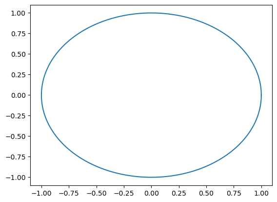

```python
plt.plot(x,y)
```

Notice: the graph does not look circular. We need to adjust the aspect ratio (i.e. the horizontal:vertical ratio) to correct this. First, a little more information on the structure of figures in matplotlib. When plotting with `matplotlib.pyplot`:

- Each figure starts with a `figure` object.
- Within that figure object, we can place an `axes` object (or several).
- On an `axes` object, we can draw things (lines, points, etc.).

When we call `plt.plot` (in the absence of other surrounding commands), `matplotlib` automatically generates a figure and axes object. We can also take control of that process ourselves:

- Calling `plt.figure()` will generate a figure object.

**Exercise:** Create two figures, one which graphs $x$ vs $y$ (as in the code above), and another that graphs both $x(t)$ and $y(t)$ vs $t$.

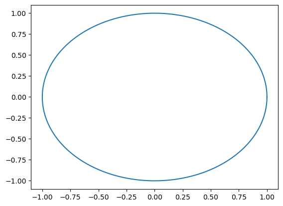

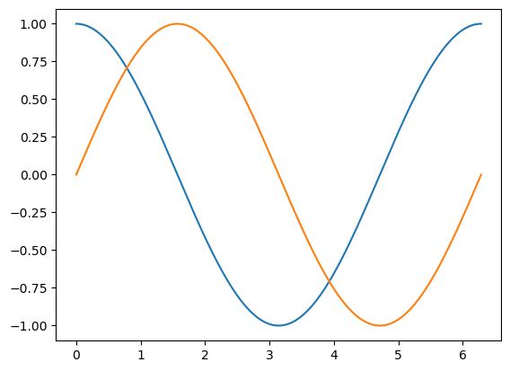

```python
plt.figure()
plt.plot(x,y)

plt.figure()
plt.plot(t,x)
plt.plot(t,y)
```

By defining the figure object ourselves, we are able to take more control and can include numerous optional arguments to change the default behavior. For example, the optional argument `figsize=(<horizontal size>, <vertical size>)` can be used to change the size of the figure. Let's graph the circle again, but this time specify a figure size that is square.

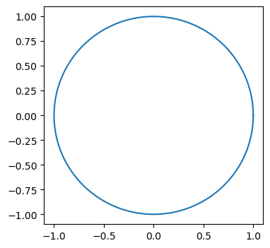

```python
plt.figure(figsize=(4,4))
plt.plot(x,y)
```

Now suppose we want to graph a second circle centered at $(3,0)$.

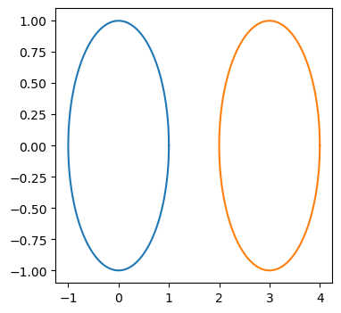

```python
plt.figure(figsize=(4,4))
plt.plot(x,y)

plt.plot(x + 3, y)
```

We see that neither circle is circular. Unfortunately, using the figure size is not a robust way to set aspect ratios. Instead, we can take control of the aspect ratio through the `axes` object. To do so, we will need to add an `axes` object ourselves. Calling the `plt.subplot` function is one mechanism for adding an axes object to a figure.

The `plt.subplot` function can take in an optional argument, `aspect`. We can use `aspect='equal'` to force an equal aspect ratio.

*Note: by default, `matplotlib` will shrink the figure to (approximately) the extents of the data. As a result, when forcing an equal aspect ratio, the resulting figure may end up smaller than the specified `figsize`.*

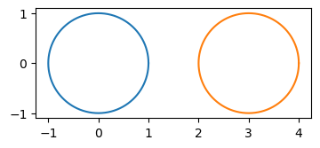

```python
plt.figure(figsize=(4,4))
plt.subplot(aspect='equal')

plt.plot(x,y)
plt.plot(x+3, y)
```

## Subplots using `plt.subplot`

We've seen how we can use the `plt.subplot` function to take control of creating an axes object within a figure.

We can call `plt.subplot` several times to create several axes objects within the same figure. In particular: `plt.subplot(r, c, n)` will create an axes object positioned within an `r` by `c` grid of subplots and insert the axes object in the `n`th position. These subplot positions are counted starting in the top-left corner, then proceeding left-to-right, then top-to-bottom.

*Note: Because `matplotlib.pyplot` is an implementation of plotting functions from MATLAB (which is not a 0-based indexing language), the subplot positions are counted starting from `1` rather than `0`.*

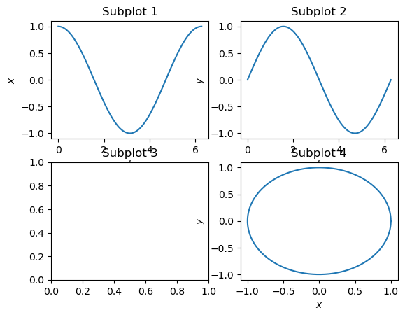

```python
plt.figure()
plt.subplot(2,2,1)        # Top-left subplot in a 2x2 grid
plt.plot(t,x)
plt.xlabel('$t$')
plt.ylabel('$x$')
plt.title('Subplot 1')

plt.subplot(2,2,2)        # Top-right subplot in a 2x2 grid
plt.plot(t,y)
plt.xlabel('$t$')
plt.ylabel('$y$')
plt.title('Subplot 2')

plt.subplot(2,2,3)        # Bottom-left subplot in a 2x2 grid
plt.title('Subplot 3')

plt.subplot(2,2,4)        # Bottom-right subplot in a 2x2 grid
plt.plot(x,y)
plt.xlabel('$x$')
plt.ylabel('$y$')
plt.title('Subplot 4')
```

**Exercise:** Create a $3\times 4$ grid of subplots, where the $n^\text{th}$ subplot graphs $y = \cos(nt)$ over the interval $0 \leq t \leq 2\pi$ for $n = 1, 2, \dots, 12$. Add a title to each subplot identifying which function is being graphed.

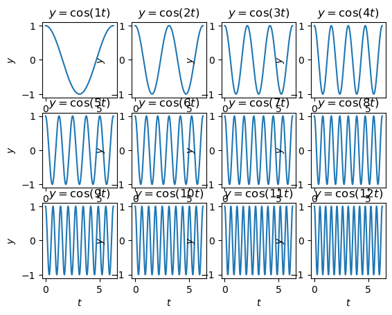

```python
plt.figure()

t = np.linspace(0,2*np.pi,1000)

for n in range(1,13):
    plt.subplot(3,4,n)
    plt.plot(t, np.cos(n*t))
    plt.xlabel('$t$')
    plt.ylabel('$y$')
    plt.title('$y = \cos({}t)$'.format(n))
```

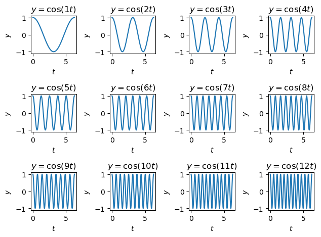

```python
plt.figure()

t = np.linspace(0,2*np.pi,1000)

for n in range(1,13):
    plt.subplot(3,4,n)
    plt.plot(t, np.cos(n*t))
    plt.xlabel('$t$')
    plt.ylabel('$y$')
    plt.title('$y = \cos({}t)$'.format(n))
plt.tight_layout()
```

When creating a figure with subplots, it can often happen that the labels of adjacent subplots will collide. The `plt.tight_layout` function can be called to have `matplotlib` automatically adjust the subplot spacing to try and avoid these collisions and remove extraneous white space.

The `plt.suptitle` function can also be used to add an overall title to a figure with several subplots.

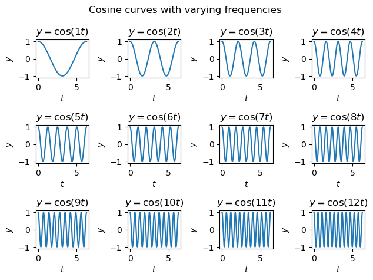

```python
plt.figure()

t = np.linspace(0,2*np.pi,1000)

for n in range(1,13):
    plt.subplot(3,4,n)
    plt.plot(t, np.cos(n*t))
    plt.xlabel('$t$')
    plt.ylabel('$y$')
    plt.title('$y = \cos({}t)$'.format(n))

plt.suptitle('Cosine curves with varying frequencies')
plt.tight_layout()
```

The arrangment of subplots can be quite flexible. For example, we can add subplots as parts of different sized grid layouts. Suppose we want to add three subplots to a figure, where the first two subplots are side by side at the top of the figure and the third subplot sits below and spans the width of the figure.

We can accomplish this by adding the first two subplots as part of a $2 \times 2$ grid in the first and second positions, then adding the third subplot as part of a $2 \times 1$ grid in the second position.

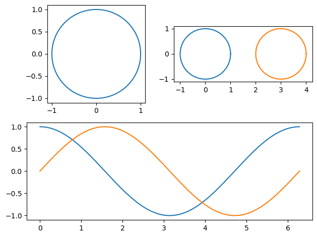

```python
plt.figure()

plt.subplot(2,2,1, aspect='equal')    # Top-left subplot of a 2x2 grid
plt.plot(x,y)

plt.subplot(2,2,2, aspect='equal')    # Top-right subplot of a 2x2 grid
plt.plot(x,y)
plt.plot(x + 3, y)

plt.subplot(2,1,2)    # Bottom subplot of a 2x1 grid
plt.plot(t,x)
plt.plot(t,y)

plt.tight_layout()
```

When adding a subplot with `plt.subplot`, the created axes object becomes "active", meaning that all plotting commands (e.g. `plt.plot`, `plt.title`, `plt.legend`, etc.) are directed toward the active axes. Sometimes we may want to go back and activate an earlier axes object to make additional changes. As long as we've stored the desired axes object (e.g. `ax = plt.subplot(...)`), then we can use the `plt.axes` function (e.g. `plt.axes(ax)`) to re-activate the axes object and continue plotting to it.